# INITIALIZERS

```python
### IMPORTS
import pandas as pd
import numpy as np
import math
import matplotlib.pyplot as plt
import matplotlib
import seaborn as sns

from sklearn.model_selection import train_test_split, GridSearchCV, StratifiedKFold
from sklearn.preprocessing import StandardScaler
from sklearn.metrics import accuracy_score, precision_score, recall_score, f1_score, confusion_matrix, classification_report
from sklearn.neighbors import KNeighborsClassifier
from sklearn.tree import DecisionTreeClassifier
from sklearn.ensemble import RandomForestClassifier
from sklearn.feature_selection import RFE, RFECV
```

```python
### A HELPER FUNCTION TO DISPLAY SECTION TITLE
def print_section(title):
    print(f'{"="*60}\n{title}\n{"="*60}')

### SEE ALL COLUMNS
pd.set_option('display.max_columns', None)
```

# DATA LOADING

```python
### LOAD DATA
train = pd.read_csv('train.csv')
test = pd.read_csv('test.csv')
```

# INITIAL DATA INSPECTION

## GET OVERVIEW

```python
### TRAIN DATASET
print_section('TRAIN')
train.info()
display(train.head())
display(train.describe())

### TEST DATASET
print_section('TEST')
test.info()
display(test.head())
display(test.describe())
```

```
============================================================
TRAIN
============================================================
<class 'pandas.core.frame.DataFrame'>
RangeIndex: 614 entries, 0 to 613
Data columns (total 10 columns):
 #   Column                 Non-Null Count  Dtype
---  ------                 --------------  -----
 0   p_id                   614 non-null    int64
 1   no_times_pregnant      614 non-null    int64
 2   glucose_concentration  614 non-null    int64
 3   blood_pressure         614 non-null    int64
 4   skin_fold_thickness    614 non-null    int64
 5   serum_insulin          614 non-null    int64
 6   bmi                    614 non-null    float64
 7   diabetes pedigree      614 non-null    float64
 8   age                    614 non-null    int64
 9   diabetes               614 non-null    int64
dtypes: float64(2), int64(8)
memory usage: 48.1 KB
```

|  | p_id | no_times_pregnant | glucose_concentration | blood_pressure | skin_fold_thickness | serum_insulin | bmi | diabetes pedigree | age | diabetes |
| --- | --- | --- | --- | --- | --- | --- | --- | --- | --- | --- |
| 0 | 316 | 2 | 112 | 68 | 22 | 94 | 34.1 | 0.315 | 26 | 0 |
| 1 | 25 | 11 | 143 | 94 | 33 | 146 | 36.6 | 0.254 | 51 | 1 |
| 2 | 710 | 2 | 93 | 64 | 32 | 160 | 38.0 | 0.674 | 23 | 1 |
| 3 | 658 | 1 | 120 | 80 | 48 | 200 | 38.9 | 1.162 | 41 | 0 |
| 4 | 542 | 3 | 128 | 72 | 25 | 190 | 32.4 | 0.549 | 27 | 1 |

|  | p_id | no_times_pregnant | glucose_concentration | blood_pressure | skin_fold_thickness | serum_insulin | bmi | diabetes pedigree | age | diabetes |
| --- | --- | --- | --- | --- | --- | --- | --- | --- | --- | --- |
| count | 614.000000 | 614.000000 | 614.000000 | 614.000000 | 614.000000 | 614.000000 | 614.000000 | 614.000000 | 614.000000 | 614.000000 |
| mean | 385.773616 | 3.853420 | 120.542345 | 68.765472 | 20.244300 | 79.355049 | 31.909935 | 0.466342 | 33.325733 | 0.348534 |
| std | 223.603024 | 3.358126 | 31.252286 | 19.914836 | 15.886083 | 117.709950 | 8.007699 | 0.331090 | 11.929569 | 0.476895 |
| min | 1.000000 | 0.000000 | 0.000000 | 0.000000 | 0.000000 | 0.000000 | 0.000000 | 0.078000 | 21.000000 | 0.000000 |
| 25% | 191.250000 | 1.000000 | 99.000000 | 62.000000 | 0.000000 | 0.000000 | 27.300000 | 0.240250 | 24.000000 | 0.000000 |
| 50% | 387.000000 | 3.000000 | 117.000000 | 72.000000 | 23.000000 | 17.000000 | 32.000000 | 0.361000 | 29.000000 | 0.000000 |
| 75% | 572.750000 | 6.000000 | 139.000000 | 80.000000 | 32.000000 | 126.000000 | 36.600000 | 0.613500 | 41.000000 | 1.000000 |
| max | 768.000000 | 17.000000 | 197.000000 | 114.000000 | 63.000000 | 846.000000 | 59.400000 | 2.420000 | 81.000000 | 1.000000 |

```
============================================================
TEST
============================================================
<class 'pandas.core.frame.DataFrame'>
RangeIndex: 154 entries, 0 to 153
Data columns (total 9 columns):
 #   Column                 Non-Null Count  Dtype
---  ------                 --------------  -----
 0   p_id                   154 non-null    int64
 1   no_times_pregnant      154 non-null    int64
 2   glucose_concentration  154 non-null    int64
 3   blood_pressure         154 non-null    int64
 4   skin_fold_thickness    154 non-null    int64
 5   serum_insulin          154 non-null    int64
 6   bmi                    154 non-null    float64
 7   diabetes pedigree      154 non-null    float64
 8   age                    154 non-null    int64
dtypes: float64(2), int64(7)
memory usage: 11.0 KB
```

|  | p_id | no_times_pregnant | glucose_concentration | blood_pressure | skin_fold_thickness | serum_insulin | bmi | diabetes pedigree | age |
| --- | --- | --- | --- | --- | --- | --- | --- | --- | --- |
| 0 | 437 | 12 | 140 | 85 | 33 | 0 | 37.4 | 0.244 | 41 |
| 1 | 411 | 6 | 102 | 90 | 39 | 0 | 35.7 | 0.674 | 28 |
| 2 | 639 | 7 | 97 | 76 | 32 | 91 | 40.9 | 0.871 | 32 |
| 3 | 213 | 7 | 179 | 95 | 31 | 0 | 34.2 | 0.164 | 60 |
| 4 | 181 | 6 | 87 | 80 | 0 | 0 | 23.2 | 0.084 | 32 |

|  | p_id | no_times_pregnant | glucose_concentration | blood_pressure | skin_fold_thickness | serum_insulin | bmi | diabetes pedigree | age |
| --- | --- | --- | --- | --- | --- | --- | --- | --- | --- |
| count | 154.000000 | 154.000000 | 154.000000 | 154.000000 | 154.000000 | 154.000000 | 154.000000 | 154.000000 | 154.000000 |
| mean | 379.422078 | 3.811688 | 122.298701 | 70.461039 | 21.701299 | 81.571429 | 32.322078 | 0.493942 | 32.902597 |
| std | 215.338912 | 3.425719 | 34.769480 | 16.935917 | 16.213095 | 105.178271 | 7.386724 | 0.332439 | 11.090106 |
| min | 4.000000 | 0.000000 | 0.000000 | 0.000000 | 0.000000 | 0.000000 | 0.000000 | 0.084000 | 21.000000 |
| 25% | 194.250000 | 1.000000 | 97.000000 | 64.000000 | 0.000000 | 0.000000 | 28.150000 | 0.248000 | 24.000000 |
| 50% | 383.000000 | 3.000000 | 115.000000 | 72.000000 | 24.500000 | 52.000000 | 32.900000 | 0.411500 | 29.500000 |
| 75% | 583.250000 | 6.000000 | 144.750000 | 78.000000 | 33.000000 | 129.500000 | 36.200000 | 0.654750 | 40.000000 |
| max | 738.000000 | 14.000000 | 199.000000 | 122.000000 | 99.000000 | 474.000000 | 67.100000 | 2.137000 | 66.000000 |

### REMARKS

- 5 non-zero numeric features (`glucose_concentration`, `blood_pressure`, `skin_fold_thickness`, `serum_insulin`, `bmi`) have invalid zeros.
- No column has any missing values.

## IDENTIFY ISSUES FOR DATA CLEANING

A systematic check on potential data issues.

### CHECK DATA TYPES

- Are all the columns in both datasets numeric (`int64` or `float64`)?
- Only numeric columns are used in building ML models.

```python
print_section('CHECK DATA TYPES')

def check_data_types(df, name):
    if df.columns.equals(df.select_dtypes(include=['float64', 'int64']).columns):
        print(f'✅ {name}: All data types are numeric (float64 or int64).')
    else:
        print(f'❌ {name}: There are non-numeric data types.')

check_data_types(train, 'train')
check_data_types(test, 'test')
```

```
============================================================
CHECK DATA TYPES
============================================================
✅ train: All data types are numeric (float64 or int64).
✅ test: All data types are numeric (float64 or int64).
```

### CHECK DUPLICATES

- Are there any duplicated rows?
- Are there any duplicated id?

```python
print_section('CHECK ROW DUPLICATES')

def check_row_dup(df, name):
    row_dup = df.duplicated().sum()
    if row_dup == 0:
        print(f'✅ {name}: {row_dup} row duplicate found.')
    else:
        print(f'❌ {name}: {row_dup} row duplicates found.')

check_row_dup(train, 'train')
check_row_dup(test, 'test')
```

```
============================================================
CHECK ROW DUPLICATES
============================================================
✅ train: 0 row duplicate found.
✅ test: 0 row duplicate found.
```

```python
print_section('CHECK ID DUPLICATES')

def check_id_dup(df, name):
    total_entries = len(df)
    unique_id = df['p_id'].nunique()
    print(f"Total entries: {total_entries}")
    print(f"Unique p_id: {unique_id}")
    if total_entries == unique_id:
        print(f'✅ {name}: No id duplicate found. 1 unique p_id per patient.\n')
    else:
        print(f'❌ {name}: Multiple entries per patient detected!\n')

check_id_dup(train, 'train')
check_id_dup(test, 'test')
```

```
============================================================
CHECK ID DUPLICATES
============================================================
Total entries: 614
Unique p_id: 614
✅ train: No id duplicate found. 1 unique p_id per patient.

Total entries: 154
Unique p_id: 154
✅ test: No id duplicate found. 1 unique p_id per patient.
```

### CHECK MISSING VALUES

- Are there any columns with missing values?
- If yes, how much do the missing values account for?

```python
print_section('CHECK MISSING VALUES')

def check_missing(df, name):
    ### COUNT OF MISSING VALUES
    miss_cnt = df.isnull().sum()

    ### PERCENTAGE OF MISSING VALUES ROUNDED TO 2 DP
    miss_pct = (miss_cnt / len(df) * 100).round(2)

    ### DF CONTAINING COLUMNS WITH MISSING VALUES
    miss_df = pd.DataFrame({'missing_count': miss_cnt[miss_cnt>0],
                               'missing_percentage': miss_pct[miss_pct>0]}) \
                    .sort_values('missing_count', ascending=False)

    if len(miss_df) > 0:
        print('\nColumns with missing values:')
        print(miss_df)
        print(f"\n❌ {name}: Missing values detected.")
        print('Remove columns with % missing more than threshold in DATA CLEANING.')
    else:
        print(miss_cnt)
        print(f"✅ {name}: No missing values detected.\n")

check_missing(train, 'train')
check_missing(test, 'test')
```

```
============================================================
CHECK MISSING VALUES
============================================================
p_id                     0
no_times_pregnant        0
glucose_concentration    0
blood_pressure           0
skin_fold_thickness      0
serum_insulin            0
bmi                      0
diabetes pedigree        0
age                      0
diabetes                 0
dtype: int64
✅ train: No missing values detected.

p_id                     0
no_times_pregnant        0
glucose_concentration    0
blood_pressure           0
skin_fold_thickness      0
serum_insulin            0
bmi                      0
diabetes pedigree        0
age                      0
dtype: int64
✅ test: No missing values detected.
```

### CHECK INVALID VALUES

- Are there any columns with invalid values, i.e. values that are unexpected based on domain understanding?
- From the overview earlier, 5 numerical non-zero columns have invalid zeros.

```python
### 1. DEFINE COLUMNS THAT CAN BE ZERO BUT NOT NEGATIVE
test_zero_cols = ['no_times_pregnant', 'diabetes pedigree']
train_zero_cols = test_zero_cols + ['diabetes']

### 2. DEFINE COLUMNS THAT MUST BE POSITIVE (NOT ZERO/NEGATIVE)
pos_cols = [col for col in train.columns if col not in train_zero_cols]

### 3. UDF TO IDENTIFY INVALID (ZERO/NEGATIVE) VALUES
def check_invalid(df, zero_cols, pos_cols, name):
    print_section(f"CHECK INVALID VALUES - {name}")

    ### COLUMNS THAT CAN BE ZERO BUT NOT NEGATIVE
    neg_only_cnt = (df[zero_cols] < 0).sum()
    neg_only_pct = (neg_only_cnt / len(df) * 100).round(1)
    zero_df = pd.DataFrame({
        "negatives_count": neg_only_cnt,
        "negatives_percent": neg_only_pct
    })
    print("1. COLUMNS THAT CAN BE ZERO BUT NOT NEGATIVE (CHECK NEGATIVE)")
    display(zero_df)

    ### COLUMNS THAT MUST BE POSITIVE (NOT ZERO/NEGATIVE)
    zero_cnt = (df[pos_cols] == 0).sum()
    zero_pct = (zero_cnt / len(df) * 100).round(1)
    neg_cnt = (df[pos_cols] < 0).sum()
    neg_pct = (neg_cnt / len(df) * 100).round(1)
    pos_df = pd.DataFrame({
        "zeros_count": zero_cnt,
        "zeros_percent": zero_pct,
        "negatives_count": neg_cnt,
        "negatives_percent": neg_pct
    })
    print("2. COLUMNS THAT MUST BE POSITIVE (CHECK ZERO/NEGATIVE)")
    display(pos_df)

    return zero_df, pos_df

### 4. OUTPUT
train_zero, train_pos = check_invalid(train, train_zero_cols, pos_cols, 'TRAIN')
test_zero, test_pos = check_invalid(test, test_zero_cols, pos_cols, 'TEST')
```

```
============================================================
CHECK INVALID VALUES - TRAIN
============================================================
1. COLUMNS THAT CAN BE ZERO BUT NOT NEGATIVE (CHECK NEGATIVE)
```

|  | negatives_count | negatives_percent |
| --- | --- | --- |
| no_times_pregnant | 0 | 0.0 |
| diabetes pedigree | 0 | 0.0 |
| diabetes | 0 | 0.0 |

```
2. COLUMNS THAT MUST BE POSITIVE (CHECK ZERO/NEGATIVE)
```

|  | zeros_count | zeros_percent | negatives_count | negatives_percent |
| --- | --- | --- | --- | --- |
| p_id | 0 | 0.0 | 0 | 0.0 |
| glucose_concentration | 4 | 0.7 | 0 | 0.0 |
| blood_pressure | 31 | 5.0 | 0 | 0.0 |
| skin_fold_thickness | 187 | 30.5 | 0 | 0.0 |
| serum_insulin | 304 | 49.5 | 0 | 0.0 |
| bmi | 10 | 1.6 | 0 | 0.0 |
| age | 0 | 0.0 | 0 | 0.0 |

```
============================================================
CHECK INVALID VALUES - TEST
============================================================
1. COLUMNS THAT CAN BE ZERO BUT NOT NEGATIVE (CHECK NEGATIVE)
```

|  | negatives_count | negatives_percent |
| --- | --- | --- |
| no_times_pregnant | 0 | 0.0 |
| diabetes pedigree | 0 | 0.0 |

```
2. COLUMNS THAT MUST BE POSITIVE (CHECK ZERO/NEGATIVE)
```

|  | zeros_count | zeros_percent | negatives_count | negatives_percent |
| --- | --- | --- | --- | --- |
| p_id | 0 | 0.0 | 0 | 0.0 |
| glucose_concentration | 1 | 0.6 | 0 | 0.0 |
| blood_pressure | 4 | 2.6 | 0 | 0.0 |
| skin_fold_thickness | 40 | 26.0 | 0 | 0.0 |
| serum_insulin | 70 | 45.5 | 0 | 0.0 |
| bmi | 1 | 0.6 | 0 | 0.0 |
| age | 0 | 0.0 | 0 | 0.0 |

#### REMARKS

- ❌ Both train and test datasets have 5 non-zero columns with invalid zero values.
- We shall treat the invalid values as "missing values".
- In `DATA CLEANING`, the columns with "missing values (invalid values)" above a percentage threshold will be dropped, whereas the others below the threshold will be imputed using median.
- Invalid value threshold: 30%
- Columns to impute: `glucose_concentration`, `blood_pressure`, `bmi`
- Columns to drop: `skin_fold_thickness`, `serum_insulin`
- `skin_fold_thickness` is decided to be dropped.
  - It has significant invalid percent (26% and 30.5%).
  - It is a proxy for body fat, which is sufficiently represented by `bmi`.
  - Imputing will likely introduce bias for marginal gain in model performance.

### CHECK OUTLIERS

- Methods: IQR & box plot.
- TRAIN dataset is used for the bounds for both TRAIN dataset & TEST dataset.

```python
### DEFINE FEATURES (EXCLUDE ID & TARGET)
feature_cols = [c for c in train.columns if c not in ['p_id', 'diabetes']]
print(f"Feature columns for outlier detection: {feature_cols}")
print(f"\nTotal: {len(feature_cols)}")

### UDF TO COMPUTE IQR BOUNDARIES
# For each column in col, compute IQR-based lower and upper bounds.
# Returns (lower, upper) where lower = Q1 - 1.5*IQR and upper = Q3 + 1.5*IQR.
def compute_iqr_bounds(df, col):
    s = df[col]
    Q1 = s.quantile(0.25)
    Q3 = s.quantile(0.75)
    IQR = Q3 - Q1
    lower = Q1 - 1.5 * IQR
    upper = Q3 + 1.5 * IQR
    return lower, upper

### UDF TO COUNT OUTLIERS BEFORE CAPPING
def outlier_counts_by_bounds(df, cols, bounds_source='train'):
    counts = {}
    ### FOR EACH COLUMN IN COLS
    for col in cols:
        s = df[col]
        ### COMPUTE IQR BOUNDS
        lower, upper = compute_iqr_bounds(df, col)
        ### COUNT OUTLIERS OUTSIDE THOSE BOUNDS
        counts[col] = int(((s < lower) | (s > upper)).sum())
    return pd.Series(counts)
```

```
Feature columns for outlier detection: ['no_times_pregnant', 'glucose_concentration', 'blood_pressure', 'skin_fold_thickness', 'serum_insulin', 'bmi', 'diabetes pedigree', 'age']

Total: 8
```

```
============================================================
CHECK OUTLIERS (OUTSIDE IQR BOUNDS OF TRAIN)
============================================================
```

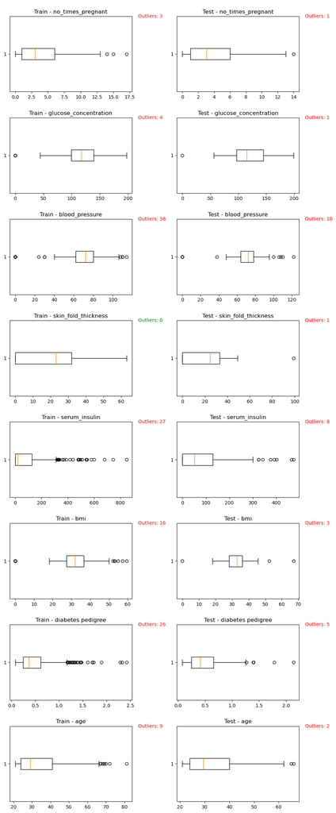

```python
### PREP THE SUBPLOT GRID
n_featureCols = len(feature_cols)
ncols = 2  # TRAIN | TEST
nrows = n_featureCols  # ONE ROW PER FEATURE
fig, axes = plt.subplots(nrows, ncols, figsize=(10, nrows*3))

print_section('CHECK OUTLIERS (OUTSIDE IQR BOUNDS OF TRAIN)')

### GET OUTLIER COUNTS
before_train_counts = outlier_counts_by_bounds(train, feature_cols)
before_test_counts = outlier_counts_by_bounds(test, feature_cols)

### FOR EACH COLUMN IN TRAIN/TEST, PLOT THE BOXPLOT & SHOW OUTLIER COUNT
for i, c in enumerate(feature_cols):
    ### TRAIN BOXPLOT (LEFT COLUMN)
    axes[i, 0].boxplot(train[c], vert=False)
    axes[i, 0].set_title(f'\nTrain - {c}')
    ### RED IF OUTLIERS; GREEN IF NO OUTLIERS
    train_color = 'green' if before_train_counts[c] == 0 else 'red'
    axes[i, 0].text(1.05, 1, f"Outliers: {before_train_counts[c]}",
                    transform=axes[i, 0].transAxes, fontsize=10, color=train_color, va='center')

    axes[i, 1].boxplot(test[c], vert=False)
    axes[i, 1].set_title(f'\nTest - {c}')
    ### RED IF OUTLIERS; GREEN IF NO OUTLIERS
    test_color = 'green' if before_test_counts[c] == 0 else 'red'
    axes[i, 1].text(1.05, 1, f"Outliers: {before_test_counts[c]}",
                    transform=axes[i, 1].transAxes, fontsize=10, color=test_color, va='center')

plt.tight_layout()
plt.show()
```

#### REMARKS

- ❌ Both datasets have outliers, except `skin_fold_thickness` in train.
- We shall ignore the outlier plots in `skin_fold_thickness` and `insulin_serum` which will be dropped later in `DATA CLEANING`.
- For other outliers, they will be **intentionally left unmodified** during `DATA CLEANING` as they represent legitimate, extreme patient medical characteristics, rather than systematic data errors, due to the small percentage they account for.

# DATA CLEANING

- From `INITIAL DATA INSPECTION`, there are no invalid data types, duplicates, or missing values.
- Columns with invalid values will be imputed or dropped.
- Outliers will be left unmodified.

## HANDLE INVALID VALUES

From `INITIAL DATA INSPECTION`,

- Invalid value threshold: 30%
- Columns to impute: `glucose_concentration`, `blood_pressure`, `bmi`
- Columns to drop: `skin_fold_thickness`, `serum_insulin`
- `skin_fold_thickness` is decided to be dropped.
  - It has significant invalid percent (26% and 30.5%).
  - It is a proxy for body fat, which is sufficiently represented by `bmi`.
  - Imputing will likely introduce bias for marginal gain in model performance.

```python
print_section('HANDLE INVALID VALUES')

### DEFINE COLUMNS TO DROP/IMPUTE
cols_drop = ['skin_fold_thickness', 'serum_insulin']
cols_imp = ['glucose_concentration', 'blood_pressure', 'bmi']

### DROP COLUMNS & CREATE COPIES FOR IMPUTATION
print(f"Dropping columns {cols_drop}...\n")
train_imp = train.drop(cols_drop, axis=1).copy()
test_imp = test.drop(cols_drop, axis=1).copy()

### SANITY CHECK
print(f"Train: {train.shape} -> {train_imp.shape}")
print(f"Test: {test.shape} -> {test_imp.shape}")

### IMPUTE ZEROS WITH TRAIN'S MEDIAN VALUES
print(f"\nImputing zeros in {cols_imp}...\n")
for col in cols_imp:
    ### IMPUTE
    median_val = train_imp[col].median()
    train_imp[col] = train_imp[col].replace(0, median_val)
    test_imp[col] = test_imp[col].replace(0, median_val)

    ### SANITY CHECK
    zeros_train = (train_imp[col] == 0).sum()
    zeros_test = (test_imp[col] == 0).sum()
    print(f"{col}: train zeros = {zeros_train}, test zeros = {zeros_test}")

### LAST CHECK
print("\nColumn Stats")
display(train_imp.describe())
display(test_imp.describe())
```

```
============================================================
HANDLE INVALID VALUES
============================================================
Dropping columns ['skin_fold_thickness', 'serum_insulin']...

Train: (614, 10) -> (614, 8)
Test: (154, 9) -> (154, 7)

Imputing zeros in ['glucose_concentration', 'blood_pressure', 'bmi']...

glucose_concentration: train zeros = 0, test zeros = 0
blood_pressure: train zeros = 0, test zeros = 0
bmi: train zeros = 0, test zeros = 0

Column Stats
```

|  | p_id | no_times_pregnant | glucose_concentration | blood_pressure | bmi | diabetes pedigree | age | diabetes |
| --- | --- | --- | --- | --- | --- | --- | --- | --- |
| count | 614.000000 | 614.000000 | 614.000000 | 614.000000 | 614.000000 | 614.000000 | 614.000000 | 614.000000 |
| mean | 385.773616 | 3.853420 | 121.304560 | 72.400651 | 32.431107 | 0.466342 | 33.325733 | 0.348534 |
| std | 223.603024 | 3.358126 | 29.688213 | 12.031595 | 6.873171 | 0.331090 | 11.929569 | 0.476895 |
| min | 1.000000 | 0.000000 | 44.000000 | 24.000000 | 18.200000 | 0.078000 | 21.000000 | 0.000000 |
| 25% | 191.250000 | 1.000000 | 100.000000 | 64.000000 | 27.500000 | 0.240250 | 24.000000 | 0.000000 |
| 50% | 387.000000 | 3.000000 | 117.000000 | 72.000000 | 32.000000 | 0.361000 | 29.000000 | 0.000000 |
| 75% | 572.750000 | 6.000000 | 139.000000 | 80.000000 | 36.600000 | 0.613500 | 41.000000 | 1.000000 |
| max | 768.000000 | 17.000000 | 197.000000 | 114.000000 | 59.400000 | 2.420000 | 81.000000 | 1.000000 |

|  | p_id | no_times_pregnant | glucose_concentration | blood_pressure | bmi | diabetes pedigree | age |
| --- | --- | --- | --- | --- | --- | --- | --- |
| count | 154.000000 | 154.000000 | 154.000000 | 154.000000 | 154.00000 | 154.000000 | 154.000000 |
| mean | 379.422078 | 3.811688 | 123.058442 | 72.331169 | 32.52987 | 0.493942 | 32.902597 |
| std | 215.338912 | 3.425719 | 33.328085 | 12.392310 | 6.90599 | 0.332439 | 11.090106 |
| min | 4.000000 | 0.000000 | 56.000000 | 38.000000 | 18.20000 | 0.084000 | 21.000000 |
| 25% | 194.250000 | 1.000000 | 97.500000 | 66.000000 | 28.37500 | 0.248000 | 24.000000 |
| 50% | 383.000000 | 3.000000 | 115.500000 | 72.000000 | 32.90000 | 0.411500 | 29.500000 |
| 75% | 583.250000 | 6.000000 | 144.750000 | 78.000000 | 36.20000 | 0.654750 | 40.000000 |
| max | 738.000000 | 14.000000 | 199.000000 | 122.000000 | 67.10000 | 2.137000 | 66.000000 |

## LATEST CLEANED DATA

```python
train_clean = train_imp.copy()
test_clean = test_imp.copy()
feature_cols_clean = [c for c in train_clean.columns if c not in ['p_id', 'diabetes']]
print(f"Feature Columns After Cleaning: {feature_cols_clean}\n")

print_section('TRAIN_CLEAN')
train_clean.info()
display(train_clean.head())
print_section('TEST_CLEAN')
test_clean.info()
display(test_clean.head())

print('''
✅ DATA CLEANING COMPLETED!
- TRAIN DATASET IS READY FOR EDA.
- TEST DATASET IS READY FOR FEATURE ENGINEERING.
''')
```

```
Feature Columns After Cleaning: ['no_times_pregnant', 'glucose_concentration', 'blood_pressure', 'bmi', 'diabetes pedigree', 'age']

============================================================
TRAIN_CLEAN
============================================================
<class 'pandas.core.frame.DataFrame'>
RangeIndex: 614 entries, 0 to 613
Data columns (total 8 columns):
 #   Column                 Non-Null Count  Dtype
---  ------                 --------------  -----
 0   p_id                   614 non-null    int64
 1   no_times_pregnant      614 non-null    int64
 2   glucose_concentration  614 non-null    int64
 3   blood_pressure         614 non-null    int64
 4   bmi                    614 non-null    float64
 5   diabetes pedigree      614 non-null    float64
 6   age                    614 non-null    int64
 7   diabetes               614 non-null    int64
dtypes: float64(2), int64(6)
memory usage: 38.5 KB
```

|  | p_id | no_times_pregnant | glucose_concentration | blood_pressure | bmi | diabetes pedigree | age | diabetes |
| --- | --- | --- | --- | --- | --- | --- | --- | --- |
| 0 | 316 | 2 | 112 | 68 | 34.1 | 0.315 | 26 | 0 |
| 1 | 25 | 11 | 143 | 94 | 36.6 | 0.254 | 51 | 1 |
| 2 | 710 | 2 | 93 | 64 | 38.0 | 0.674 | 23 | 1 |
| 3 | 658 | 1 | 120 | 80 | 38.9 | 1.162 | 41 | 0 |
| 4 | 542 | 3 | 128 | 72 | 32.4 | 0.549 | 27 | 1 |

```
============================================================
TEST_CLEAN
============================================================
<class 'pandas.core.frame.DataFrame'>
RangeIndex: 154 entries, 0 to 153
Data columns (total 7 columns):
 #   Column                 Non-Null Count  Dtype
---  ------                 --------------  -----
 0   p_id                   154 non-null    int64
 1   no_times_pregnant      154 non-null    int64
 2   glucose_concentration  154 non-null    int64
 3   blood_pressure         154 non-null    int64
 4   bmi                    154 non-null    float64
 5   diabetes pedigree      154 non-null    float64
 6   age                    154 non-null    int64
dtypes: float64(2), int64(5)
memory usage: 8.6 KB
```

|  | p_id | no_times_pregnant | glucose_concentration | blood_pressure | bmi | diabetes pedigree | age |
| --- | --- | --- | --- | --- | --- | --- | --- |
| 0 | 437 | 12 | 140 | 85 | 37.4 | 0.244 | 41 |
| 1 | 411 | 6 | 102 | 90 | 35.7 | 0.674 | 28 |
| 2 | 639 | 7 | 97 | 76 | 40.9 | 0.871 | 32 |
| 3 | 213 | 7 | 179 | 95 | 34.2 | 0.164 | 60 |
| 4 | 181 | 6 | 87 | 80 | 23.2 | 0.084 | 32 |

```
✅ DATA CLEANING COMPLETED!
- TRAIN DATASET IS READY FOR EDA.
- TEST DATASET IS READY FOR FEATURE ENGINEERING.
```

# EDA

- EDA is done only on the TRAIN dataset without touching the TEST dataset.
- This is to prevent leaking information and artificially improving ML model performance.

```python
### SET PLOTTING STYLE
# white background, visible grey gridlines
# all figure sizes to 12 inches wide x 6 inches tall unless specified
sns.set_theme(style='whitegrid', rc={'figure.figsize': (14, 6)})
```

## TARGET VARIABLE ANALYSIS

```
============================================================
TARGET VARIABLE ANALYSIS
============================================================
Diabetes Distribution:
Non-Diabetic (0): 400 (65.1%)
Diabetic (1): 214 (34.9%)

Non-Diabetic-to-Diabetic Ratio: 1.87:1
```

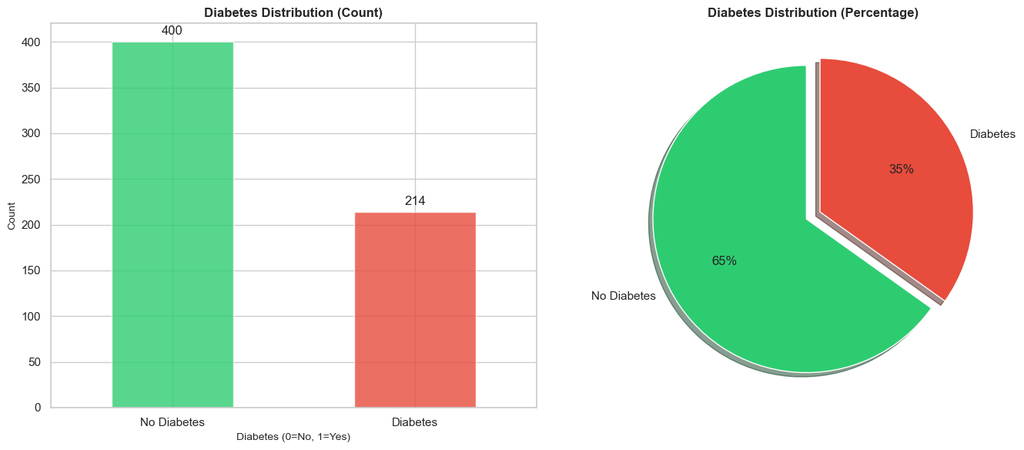

```python
print_section('TARGET VARIABLE ANALYSIS')

### SHOW COUNT AND PERCENTAGE
diabetes_count = train_clean['diabetes'].value_counts()
diabetes_pct = train_clean['diabetes'].value_counts(normalize=True) * 100

# :.1f and :.2f to round to 1 and 2 decimal place(s) respectively
print('Diabetes Distribution:')
print(f"Non-Diabetic (0): {diabetes_count[0]} ({diabetes_pct[0]:.1f}%)")
print(f"Diabetic (1): {diabetes_count[1]} ({diabetes_pct[1]:.1f}%)")
print(f"\nNon-Diabetic-to-Diabetic Ratio: {diabetes_count[0]/diabetes_count[1]:.2f}:1")

### VISUALIZE TARGET DISTRIBUTION
# Create a figure of two subplots (1 row x 2 cols)
# -------------------------------
# |   Axes[0]   |   Axes[1]     |
# -------------------------------
fig, axes = plt.subplots(1, 2)
colors = ['#2ecc71', '#e74c3c']

# Bar Chart for Axes[0]
diabetes_count.plot(kind='bar', ax=axes[0], color=colors, alpha=0.8)
axes[0].set_title('Diabetes Distribution (Count)', fontsize=12, fontweight='bold')
axes[0].set_xlabel('Diabetes (0=No, 1=Yes)', fontsize=10)
axes[0].set_ylabel('Count', fontsize=10)
axes[0].set_xticklabels(['No Diabetes', 'Diabetes'], rotation=0)

# Add count labels on bars (5 counts above current count y)
# va='bottom': the bottom of text box sits above y-coordinate = y + 5
for x, y in enumerate(diabetes_count):
    axes[0].text(x, y + 5, str(y), ha='center', va='bottom')

# Pie Chart for Axes[1]
axes[1].pie(diabetes_count, labels=['No Diabetes', 'Diabetes'],
            colors=colors, autopct='%1.0f%%', startangle=90,
            explode=(0.05, 0.05), shadow=True)
axes[1].set_title('Diabetes Distribution (Percentage)', fontsize=12, fontweight='bold')

plt.tight_layout()
plt.show()
```

### REMARKS

- The train dataset has class imbalance - 1.87 times more non-diabetic than diabetic patients.
- This can make the ML models more biased towards the majority class (non-diabetic) and predict it more frequently.
- Hence, the "accuracy" metric becomes unreliable, and cannot be the sole evaluation metric.
- During model evaluation, **use other metrics (precision, recall, F1-score) alongside accuracy** to give a better picture of a model's performance.
- https://www.geeksforgeeks.org/machine-learning/handling-imbalanced-data-for-classification/

## STATISTICAL SUMMARY BY DIABETES

```python
print_section('STATISTICAL SUMMARY BY DIABETES')

### SUMMARY STATISTICS GROUPED BY DIABETES
print('\n--- Non-Diabetic (diabetes=0) ---')
non_diabetic_stat = train_clean[train_clean['diabetes']==0][feature_cols_clean].describe()
display(non_diabetic_stat.round(2))

print('\n--- Diabetic (diabetes=1) ---')
diabetic_stat = train_clean[train_clean['diabetes']==1][feature_cols_clean].describe()
display(diabetic_stat.round(2))

### COMPARE MEDIANS BETWEEN GROUPS
print('\n--- Median Comparison: Diabetic vs Non-Diabetic ---')
median_compare = pd.DataFrame({
    'Non-Diabetic': train_clean[train_clean['diabetes']==0][feature_cols_clean].median(),
    'Diabetic': train_clean[train_clean['diabetes']==1][feature_cols_clean].median(),
})
median_compare['Difference'] = median_compare['Diabetic'] - median_compare['Non-Diabetic']
median_compare['Pct_Change'] = (median_compare['Difference'] / median_compare['Non-Diabetic'] * 100).round(0)
display(median_compare.round(2))
```

```
============================================================
STATISTICAL SUMMARY BY DIABETES
============================================================

--- Non-Diabetic (diabetes=0) ---
```

|  | no_times_pregnant | glucose_concentration | blood_pressure | bmi | diabetes pedigree | age |
| --- | --- | --- | --- | --- | --- | --- |
| count | 400.00 | 400.00 | 400.00 | 400.00 | 400.00 | 400.00 |
| mean | 3.34 | 110.41 | 70.78 | 30.94 | 0.42 | 31.39 |
| std | 3.01 | 23.78 | 11.61 | 6.58 | 0.30 | 12.00 |
| min | 0.00 | 44.00 | 24.00 | 18.20 | 0.08 | 21.00 |
| 25% | 1.00 | 94.00 | 62.00 | 25.90 | 0.23 | 23.00 |
| 50% | 2.00 | 108.00 | 72.00 | 30.10 | 0.33 | 27.00 |
| 75% | 5.00 | 124.25 | 78.00 | 35.30 | 0.55 | 37.00 |
| max | 13.00 | 197.00 | 110.00 | 57.30 | 2.33 | 81.00 |

```
--- Diabetic (diabetes=1) ---
```

|  | no_times_pregnant | glucose_concentration | blood_pressure | bmi | diabetes pedigree | age |
| --- | --- | --- | --- | --- | --- | --- |
| count | 214.00 | 214.00 | 214.00 | 214.00 | 214.00 | 214.00 |
| mean | 4.81 | 141.67 | 75.43 | 35.22 | 0.54 | 36.94 |
| std | 3.74 | 28.93 | 12.25 | 6.54 | 0.37 | 10.95 |
| min | 0.00 | 78.00 | 30.00 | 22.90 | 0.12 | 21.00 |
| 25% | 1.25 | 119.00 | 68.00 | 30.50 | 0.26 | 28.00 |
| 50% | 4.00 | 140.00 | 74.00 | 34.05 | 0.43 | 36.00 |
| 75% | 8.00 | 164.75 | 84.00 | 38.92 | 0.73 | 44.75 |
| max | 17.00 | 197.00 | 114.00 | 59.40 | 2.42 | 70.00 |

```
--- Median Comparison: Diabetic vs Non-Diabetic ---
```

|  | Non-Diabetic | Diabetic | Difference | Pct_Change |
| --- | --- | --- | --- | --- |
| no_times_pregnant | 2.00 | 4.00 | 2.00 | 100.0 |
| glucose_concentration | 108.00 | 140.00 | 32.00 | 30.0 |
| blood_pressure | 72.00 | 74.00 | 2.00 | 3.0 |
| bmi | 30.10 | 34.05 | 3.95 | 13.0 |
| diabetes pedigree | 0.33 | 0.43 | 0.11 | 32.0 |
| age | 27.00 | 36.00 | 9.00 | 33.0 |

### REMARKS

- **Median values are consistently higher in diabetic patients across all six numerical features**, indicating a systematic shift in central tendency rather than effects driven by outliers.
- The most pronounced differences are observed in glucose concentration (+30%), age (+33%), number of pregnancies (median increase from 2 to 4), and diabetes pedigree score (+32%). BMI shows a moderate increase (+13%), while blood pressure exhibits only a small median difference (+3%).
- These results are descriptive but do not imply statistical significance.

## FEATURE DISTRIBUTIONS BY DIABETES

```
============================================================
FEATURE DISTRIBUTIONS BY DIABETES
============================================================
```

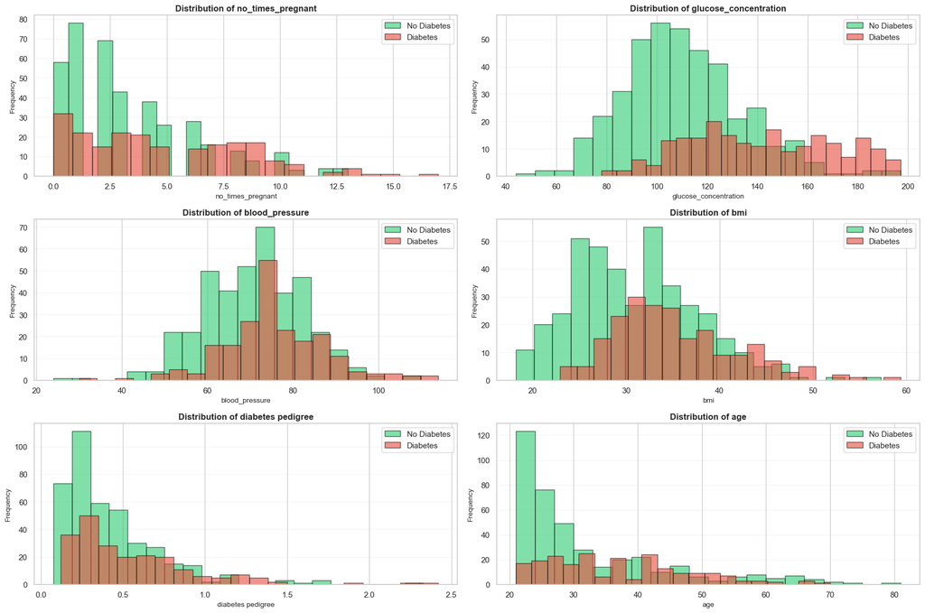

```python
print_section('FEATURE DISTRIBUTIONS BY DIABETES')

### SET THE SUBPLOT GRID SHAPE
n_cols = 2
# Count no. of rows of subplots based on feature cols
n_rows = int(np.ceil(len(feature_cols_clean) / n_cols))
# Create the grid 18-inch wide with 4 inches per row
fig, axes = plt.subplots(n_rows, n_cols, figsize=(18, n_rows*4))
# Flatten the 2D array of axes (n_rows, n_cols) to 1D for easy indexing of each subplot as axes(idx)
axes = axes.ravel()

### FOR EVERY COLUMN AND ITS ENUMERATED INDEX IN feature_cols_clean
for idx, col in enumerate(feature_cols_clean):
    ### PLOT FOR NON-DIABETIC
    train_clean[train_clean['diabetes']==0][col].hist(
        bins=20, alpha=0.6, label='No Diabetes',
        color=colors[0], ax=axes[idx], edgecolor='black'
    )
    ### PLOT FOR DIABETIC
    train_clean[train_clean['diabetes']==1][col].hist(
        bins=20, alpha=0.6, label='Diabetes',
        color=colors[1], ax=axes[idx], edgecolor='black'
    )
    ### SET PLOT ANNOTATIONS
    axes[idx].set_title(f'Distribution of {col}', fontsize=12, fontweight='bold')
    axes[idx].set_xlabel(col, fontsize=10)
    axes[idx].set_ylabel('Frequency', fontsize=10)
    axes[idx].legend()
    axes[idx].grid(axis='y', alpha=0.2)

### HIDE UNUSED SUBPLOT (IF ANY)
for idx in range(len(feature_cols_clean), len(axes)):
    axes[idx].axis('off')

plt.tight_layout()
plt.show()
```

### REMARKS

- Obvious difference in distributions of `glucose_concentration`, `bmi`, and `age` between diabetic and non-diabetic patients.
- Diabetic patients tend to have **higher glucose concentration, BMI, and age**.
- Other features (`no_times_pregnant`, `blood_pressure`, `diabetes pedigree`) have similar, overlapping distributions.

## CORRELATION ANALYSIS

```
============================================================
CORRELATION ANALYSIS
============================================================
```

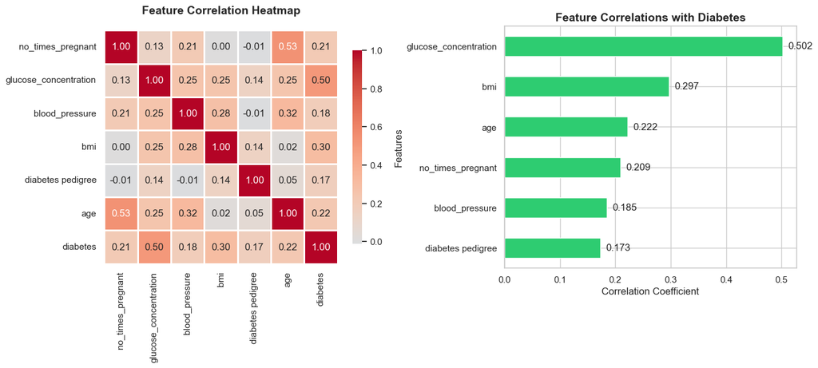

```python
print_section('CORRELATION ANALYSIS')

### CALCULATE CORRELATION MATRIX
corr_matrix = train_clean[feature_cols_clean + ['diabetes']].corr()

### CREATE A FIGURE OF TWO SUBPLOTS (1 ROW X 2 COLS)
fig, axes = plt.subplots(1, 2)

### 1. CORRELATION HEATMAP IN LEFT SUBPLOT
sns.heatmap(corr_matrix, annot=True, fmt='.2f', cmap='coolwarm',
            center=0, square=True, linewidths=1, cbar_kws={"shrink": 0.8}, ax=axes[0])
axes[0].set_title('Feature Correlation Heatmap', fontsize=14, fontweight='bold', pad=20)

### 2. HORIZONAL BAR PLOT IN RIGHT SUBPLOT
diabetes_corr = corr_matrix['diabetes'].round(3).drop('diabetes').sort_values()
# Dynamic color based on corr sign
colorsCorr = [colors[0] if x > 0 else colors[1] for x in diabetes_corr.values]
ax = diabetes_corr.plot(kind='barh', color=colorsCorr, ax=axes[1])

# Add corr values as text labels at the end of each bar
for i, (value, feature) in enumerate(zip(diabetes_corr.values, diabetes_corr.index)):
    # x-position = end of bar (value)
    # y-position = bar center (i)
    ax.text(value + 0.01 if value > 0 else value - 0.01,  # offset outside the bar; dynamic based on corr sign
            i, # y-coordinate of horizontal bar
            f"{value:.3f}",  # formatted corr value to 3 dp
            va='center',
            ha='left' if value > 0 else 'right') # outside bar; dynamic based on corr sign

axes[1].set_title('Feature Correlations with Diabetes', fontsize=14, fontweight='bold')
axes[1].set_xlabel('Correlation Coefficient', fontsize=12)
axes[1].set_ylabel('Features', fontsize=12)

plt.tight_layout()
plt.show()
```

### REMARKS

- `glucose_concentration` shows the strongest linear correlaiton with diabetes (0.50), making it the **dominant linear signal** among the features.
- `bmi` shows a moderate linear correlation with diabetes (0.30), presenting a **meaningful secondary contributor**.
- The remaining features have weak individual linear correlations with diabetes (0.17-0.22) and limited **standalone** linear association with the target.
- By domain knowledge, while glucose concentration and BMI show the strongest linear relationships with diabetes, the generally weak pairwise correlations and limited multicolinearity **motivate the exploration of nonlinear relationships and feature interactions**. Accordingly, **feature engineering will include ratios, interactions, high-risk indicator flags, and nonlinear transformations (polynomial and log)**.

## FEATURE DISTRIBUTIONS BY DIABETES

```
============================================================
FEATURE DISTRIBUTIONS BY DIABETES
============================================================
```

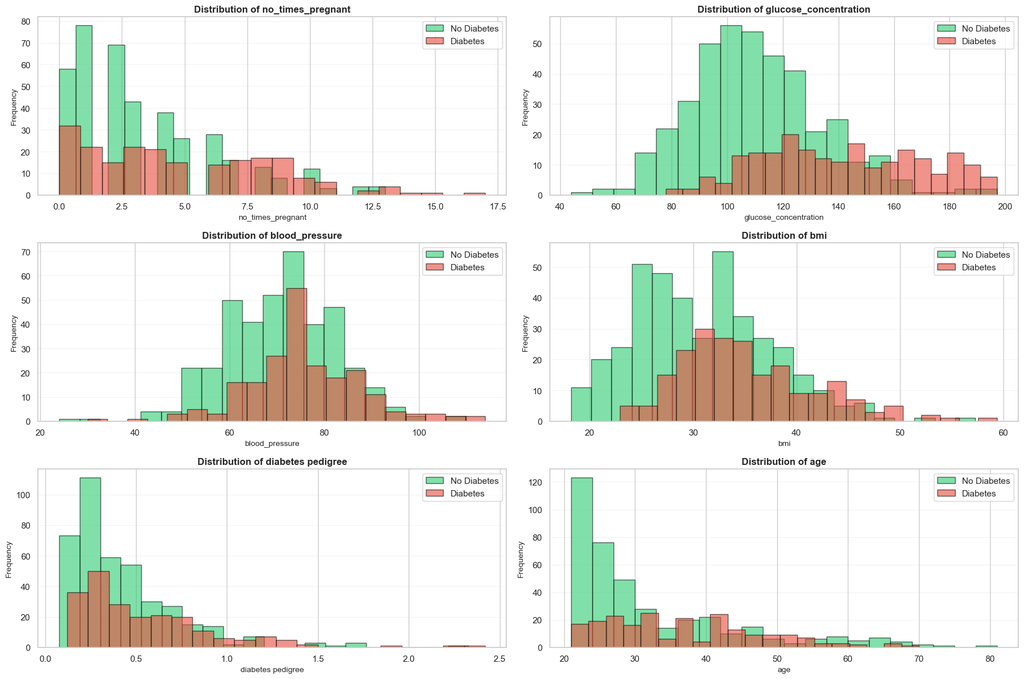

```python
print_section('FEATURE DISTRIBUTIONS BY DIABETES')

### SET THE SUBPLOT GRID SHAPE
n_cols = 2
# Count no. of rows of subplots based on feature cols
n_rows = int(np.ceil(len(feature_cols_clean) / n_cols))
# Create the grid 18-inch wide with 4 inches per row
fig, axes = plt.subplots(n_rows, n_cols, figsize=(18, n_rows*4))
# Flatten the 2D array of axes (n_rows, n_cols) to 1D for easy indexing of each subplot as axes(idx)
axes = axes.ravel()

### FOR EVERY COLUMN AND ITS ENUMERATED INDEX IN feature_cols_clean
for idx, col in enumerate(feature_cols_clean):
    ### PLOT FOR NON-DIABETIC
    train_clean[train_clean['diabetes']==0][col].hist(
        bins=20, alpha=0.6, label='No Diabetes',
        color=colors[0], ax=axes[idx], edgecolor='black'
    )
    ### PLOT FOR DIABETIC
    train_clean[train_clean['diabetes']==1][col].hist(
        bins=20, alpha=0.6, label='Diabetes',
        color=colors[1], ax=axes[idx], edgecolor='black'
    )
    ### SET PLOT ANNOTATIONS
    axes[idx].set_title(f'Distribution of {col}', fontsize=12, fontweight='bold')
    axes[idx].set_xlabel(col, fontsize=10)
    axes[idx].set_ylabel('Frequency', fontsize=10)
    axes[idx].legend()
    axes[idx].grid(axis='y', alpha=0.2)

### HIDE UNUSED SUBPLOT (IF ANY)
for idx in range(len(feature_cols_clean), len(axes)):
    axes[idx].axis('off')

plt.tight_layout()
plt.show()
```

### REMARKS

1. `glucose_concentration`
   - Shows clear class separation, with the **diabetes group right-shifted relative to non-diabetes group**.
   - While overlap exists, higher glucose values are substantially more frequent among diabetic patients.
   - Hence, glucose concentration is a **strong discriminative signal**, consistent wth its high linear correlation with the target.
2. `bmi`
   - Shows a **moderate right shift for the diabetes group**.
   - Considerable overlap exists between classes.
   - Hence, BMI is a **meaningful secondary contributor** but insufficient as a standalone discrimator, consistent with earlier correlation analysis.
3. `age`
   - Distribution indicates **higher diabetes prevalence at older ages**.
   - Non-diabetes observations are concentrated among younger age groups.
   - Class separation is nonlinear and not uniform across the full age range.
   - Hence, age likely influences diabetes risk in a **nonlinear or threshold-dependent (flag) manner**, consistent with its relatively weak linear correlation with the target.
4. `no_times_pregnant`
   - Shows a **right-skewed, class-dependent distribution**.
   - Non-diabetic observations are concentrated at lower pregnancy counts.
   - Higher counts occur more frequently among diabetic patients.
5. `blood_pressure`
   - Distributions **largely overlap** between classes.
   - Both classes share similar central tendencies, with only marginal right-tail differences among diabetic patients.
   - Blood pressure **alone offers limited discriminative value** but may contribute marginally in combination with other features.
6. `diabetes pedigree`
   - Strongly **right-skewed, with a heavier tail for diabetic patients**.
   - Higher pedigree values occur more frequently among diabetic observations.
   - Pedigree effects appear **nonlinear**, supporting the use of **transformations** or **threshold**-based engineerings.
7. **Overall**
   - Most features show substantial overlap between classes, indicating that diabetes classification is driven by **combined, conditional effects rather than single variables**.
   - `glucose_concentration` and `bmi` show **clear distributional shifts**, where the *entire* distribution for diabetic patients is displaced toward higher values. These features contribute **signal across a broad range of values** even without specific thresholds.
   - In contrast, `age`, `diabetes pedigree`, and `no_times_pregnant` show class differences *primarily* in the upper ranges, suggesting that diabetes risk increases **only when specific thresholds are crossed**.
   - As a result, diabetes classification appears to rely on a combination of:
     - **Globally informative** features (`glucose_concentration`, `bmi`), and
     - **Conditionally informative** features whose contribution emerges only at higher values or in interaction with other variables (`age`, `diabetes pedigree`, `no_times_pregnant`).
8. **Implications for feature engineering**
   - Threshold-based indicators (e.g., high glucose, high BMI).
   - Ratio & interaction features (e.g., glucose x BMI, age x pregnancies).
   - Log or polynomial transformations for skewed features (e.g., diabetes pedigree, pregancies).

## BOX PLOTS BY DIABETES

```
============================================================
BOX PLOTS BY DIABETES
============================================================
```

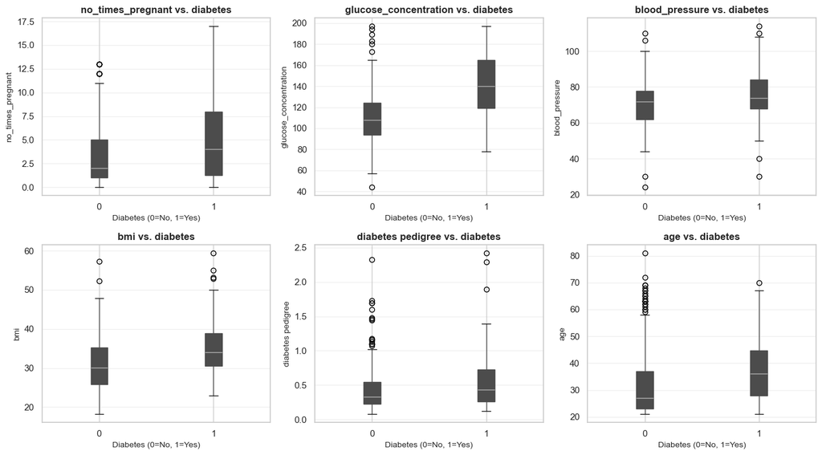

```python
print_section('BOX PLOTS BY DIABETES')

### BUILD BOX PLOTS FOR ALL FEATURES BY DIABETES
n_cols = 3
n_rows = int(np.ceil(len(feature_cols_clean) / n_cols))
fig, axes = plt.subplots(n_rows, n_cols, figsize=(14, n_rows*4))
axes = axes.ravel()

for idx, col in enumerate(feature_cols_clean):
    train_clean.boxplot(column=col, by='diabetes', ax=axes[idx], patch_artist=True, return_type='dict')
    axes[idx].set_title(f'{col} vs. diabetes', fontsize=12, fontweight='bold')
    axes[idx].set_xlabel('Diabetes (0=No, 1=Yes)', fontsize=10)
    axes[idx].set_ylabel(col, fontsize=10)
    axes[idx].grid(axis='y', alpha=0.3)

### HIDE UNUSED SUBPLOT
for idx in range(len(feature_cols_clean), len(axes)):
    axes[idx].axis('off')

plt.suptitle('')  # Remove default parent title
plt.tight_layout()
plt.show()
```

### REMARKS

1. Primary predictors: `glucose_concentration` & `bmi`
   - Both features show the most distinct separation in median values & interquartile range (IQR) between the non-diabetic and diabetic groups.
   - Feature Engineering:
     - **Threshold flags**: Create binary features for high `bmi` and high `glucose_concentration`.
2. Secondary predictors: `age` & `no_times_pregnant`
   - Both features show an upward shift in distribution for the diabetic group. While there is an overlap, the 75th percentile for non-diabetics aligns closely with the median for diabetics, suggesting these are strong secondary predictors.
   - Feature Engineering:
     - **Age binning**: Implement age bins (e.g., 20-29, 30-39, 40-49, 50+) to account for the clear "jump" in diabetes prevalence seen in the over-35 age group.
     - **Pregnancy binning**: The distribution for `no_times_pregnant` is skewed. Bin this into 0, 1-4, and 5+ to capture the risk jump seen in the widen IQR of the diabetic group.
3. Low-signal, high-variance: `blood_pressure` & `diabetes pedigree`
   - Both features show significant overlap (especially in medians & IQRs) between the two classes, along with numerous outliers.
   - `blood_pressure` medians are nearly identifical across both classes, while `diabetes pedigree` is filled with high-value outliers.
   - These features are "noisy" and may lead to overfitting if used in their raw, outlier heavy states.
   - Feature Engineering:
     - **BP binning**: Create categorical feature for `blood_pressure` with clinical bins (normal, stage 1 hypertension, stage 2 hypertension) in place of raw values when the median are this close. This converts a low-signal continuous variable into a more meaningful clinical, categorical feature.